# Greenhouse gas emissions model - making scenarios

Cory Whitney and Eike Luedeling

We’re defining the function as in 210617_GHG_model.Rmd, but there’s no need to show this again here.

## Generating the GHG emissions model

The formulas come from Chapter 10 of the *2006 IPCC Guidelines for National Greenhouse Gas Inventories* (Dong et al. 2006) (Volume 4 - Agriculture, Forestry and Other Land Use). The document can be found on [the IPCC website](https://www.ipcc-nggip.iges.or.jp/public/2006gl/pdf/4_Volume4/V4_10_Ch10_Livestock.pdf). The chapter is part of the book *Good Practice Guidance and Uncertainty Management in National Greenhouse Gas Inventories* (IPCC 2021), also on the [the IPCC website](https://www.ipcc-nggip.iges.or.jp/public/gp/english/). Many variables are based on the work done in *Variation in the carbon footprint of milk production on smallholder dairy farms in central Kenya* (Wilkes et al. 2020) and in *Methods and guidance to support MRV of livestock emissions* (Wilkes et al. 2019). We run the model with the decisionSupport package (Luedeling et al. 2021).

We load the library and the data. The data contains ranges of possible values for the simulation. Each variable is represented with a confidence interval range and a specification of the distribution shape.

## Running the model with scenarios

The normal mcSimulation function takes random draws for each of the input variables from the distributions specified in the input table. The distributions that are used are the same for every run of the Monte Carlo simulation. Sometimes it’s desirable to specify particular scenarios *a priori*, e.g. to simulate outcomes for particular farm types, climate scenarios etc. To do this, we would normally have to define separate input tables and run separate simulations. This is quite inconvenient. Here, we’ll develop a function that can do this job automatically.

The new function will consist of a wrapper around the mcSimulation function, which will be able to modify the input table according to a scenario file we provide. This file will contain information on which variables should be modified for each scenario and how many model runs should be included in the simulation.

```r
scenario_sampler<-function(base_estimate, scenarios, model_function, ..., numberOfModelRuns=NA, randomMethod = "calculate", functionSyntax="data.frameNames",
  relativeTolerance = 0.05,
  verbosity = 0)
{
  initial_estimate = estimate_read_csv(base_estimate)
  scenarios<-read.csv(scenarios)

  scenario_names<-colnames(scenarios[3:ncol(scenarios)])

  for(scens in scenario_names)
  {
    estim<-initial_estimate
    for (i in 2:nrow(scenarios))
    {if(scenarios$param[i]=="both")
      {estim$marginal[scenarios[i,1],"lower"]<-as.numeric(scenarios[i,scens])
       estim$marginal[scenarios[i,1],"upper"]<-as.numeric(scenarios[i,scens])}
     if(scenarios$param[i]=="lower")
       estim$marginal[scenarios[i,1],"lower"]<-as.numeric(scenarios[i,scens])
     if(scenarios$param[i]=="upper")
       estim$marginal[scenarios[i,1],"upper"]<-as.numeric(scenarios[i,scens])
     if(scenarios$param[i]=="distribution")
       estim$marginal[scenarios[i,1],"distribution"]<-scenarios[i,scens]
    }

    if("Runs" %in% scenarios[1,])
      n_Runs<-as.numeric(scenarios[which(scenarios[1,]=="Runs"),scens]) else
        if(!is.na(numberOfModelRuns))
          n_Runs<-numberOfModelRuns else
            stop(paste("Not clear how many times scenario", scens, "should be run"))
      if(!(n_Runs==round(n_Runs))&(n_Runs>0))
        stop(paste("Number of runs for scenario", scens, "is not a positive integer"))
    scen_results<-mcSimulation(
      estimate = estim,
      model_function = model_function,
      ...,
      numberOfModelRuns = n_Runs,
      functionSyntax = functionSyntax)
    scen_results$x[,"Scenario"]<-scens
    scen_results$y[,"Scenario"]<-scens
    if(scens==scenario_names[1])
      end_results<-scen_results
    if(!scens==scenario_names[1])
    {end_results$x<-rbind(end_results$x,scen_results$x)
     end_results$y<-rbind(end_results$y,scen_results$y)
     end_results$call<-"multi-scenario call"
     }


  }
  class(end_results) <- cbind("mcSimulation", class(end_results))
  return(end_results)
}
```

This function does the same as the mcSimulation function, but with an additional scenario_file that can be supplied. This file specifies which variables should be modified for each of the scenarios, as well as the number of model runs for for it. Here’s an example file:

```r
knitr::kable(read.csv("data/scenarios.csv"))
```

| ï..Variable | param | Scen1 | Scen2 |
| --- | --- | --- | --- |
| Runs | x | 100 | 300 |
| N_animal_type_1 | both | 100 | 4000 |
| N_animal_type_2 | lower | 100 | 10 |
| N_animal_type_2 | upper | 1000 | 20 |
| N_animal_type_2 | distribution | posnorm | norm |

Each column beyond the first two columns contains information for a particular scenario. This is restricted to the parameters that should be *changed* for this scenario. All variables that aren’t specified in this table remain at their original values given in the usual input table (which is called `base_estimate` here).

The first row (“Runs” in the first column) indicates the number of runs.

Each subsequent row indicates which value from the input table should be modified, so the string in the first column has to correspond to a variable name in the input table. The second column indicates which value should be changes, with options being “lower,” “upper,” “distribution” and “both.” If “both” is selected, both the lower and upper bounds are modified (this should only be done for constants).

```r
GHG_simulation<-scenario_sampler(base_estimate = "data/livestock_ghg_input_table.csv",
                                 scenarios = "data/scenarios.csv",
                                 model_function = ghg_emissions,
                                 functionSyntax = "plainNames")


#GHG_simulation <- mcSimulation(
#  estimate = estimate_read_csv("data/livestock_ghg_input_table.csv"),
#  model_function = ghg_emissions,
#  numberOfModelRuns = 1e4, # 10,000 runs
#  functionSyntax = "plainNames"
#)
```

Here we plot the distributions of the various outputs from the model.

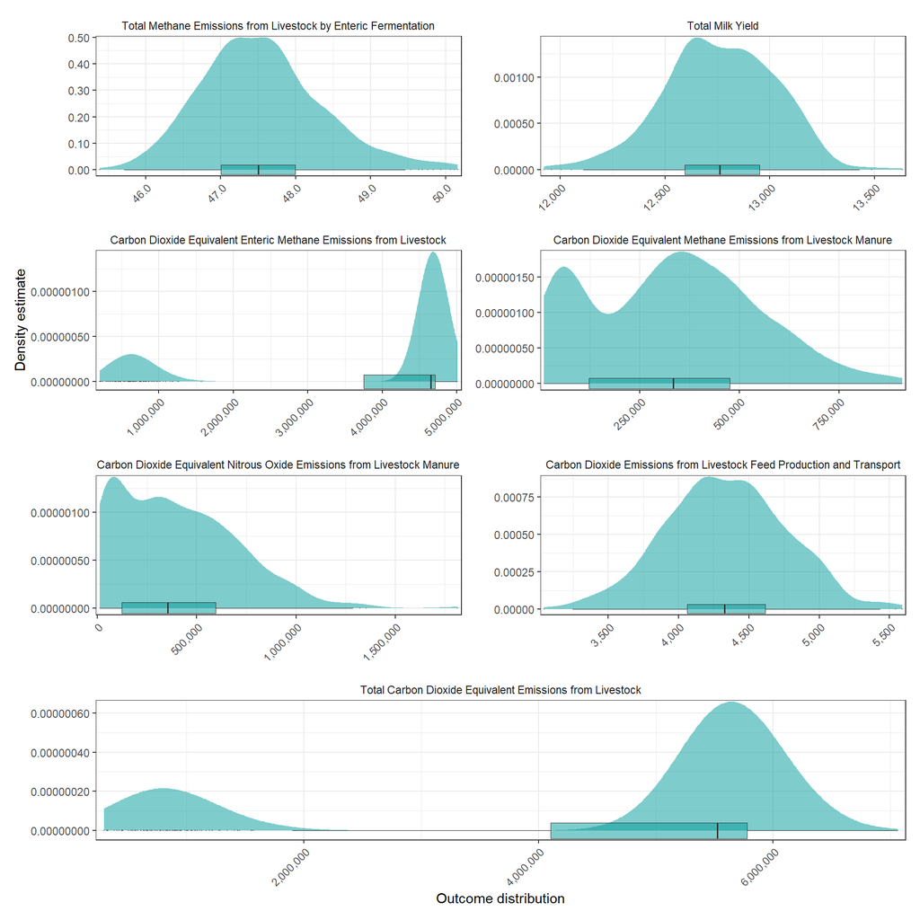

```r
# enteric_CH4=enteric_CH4,
enteric_CH4_dist_plot <- plot_distributions(mcSimulation_object = GHG_simulation,
                   vars = "enteric_CH4",
                   method = "boxplot_density",
                   old_names = "enteric_CH4",
                   new_names = "Total Methane Emissions from Livestock by Enteric Fermentation") +
  theme(axis.title.x=element_blank(),
        axis.title.y=element_blank())

# milk_yield=sum(total_milk),
milk_yield_dist_plot <- plot_distributions(mcSimulation_object = GHG_simulation,
                   vars = "milk_yield",
                   method = "boxplot_density",
                   old_names = "milk_yield",
                   new_names = "Total Milk Yield") +
  theme(axis.title.x=element_blank(),
        axis.title.y=element_blank())

# enteric_CH4_CO2eq=sum(enteric_CH4_CO2eq),
enteric_CH4_CO2eq_dist_plot <- plot_distributions(mcSimulation_object = GHG_simulation,
                   vars = "enteric_CH4_CO2eq",
                   method = "boxplot_density",
                   old_names = "enteric_CH4_CO2eq",
                   new_names = "Carbon Dioxide Equivalent Enteric Methane Emissions from Livestock") +
  theme(axis.title.x=element_blank())

# mm_CH4_CO2eq=sum(mm_CH4_CO2eq),
mm_CH4_CO2eq_dist_plot <- plot_distributions(mcSimulation_object = GHG_simulation,
                   vars = "mm_CH4_CO2eq",
                   method = "boxplot_density",
                   old_names = "mm_CH4_CO2eq",
                   new_names = "Carbon Dioxide Equivalent Methane Emissions from Livestock Manure") +
  theme(axis.title.x=element_blank(),
        axis.title.y=element_blank())

# mm_N2O_CO2eq=sum(mm_N2O_CO2eq),
mm_N2O_CO2eq_dist_plot <- plot_distributions(mcSimulation_object = GHG_simulation,
                   vars = "mm_N2O_CO2eq",
                   method = "boxplot_density",
                   old_names = "mm_N2O_CO2eq",
                   new_names = "Carbon Dioxide Equivalent Nitrous Oxide Emissions from Livestock Manure") +
  theme(axis.title.x=element_blank(),
        axis.title.y=element_blank())

# feed_CO2=feed_CO2,
feed_CO2_dist_plot <- plot_distributions(mcSimulation_object = GHG_simulation,
                   vars = "feed_CO2",
                   method = "boxplot_density",
                   old_names = "feed_CO2",
                   new_names = "Carbon Dioxide Emissions from Livestock Feed Production and Transport") +
  theme(axis.title.x=element_blank(),
        axis.title.y=element_blank())

# on_farm=sum(on_farm)
on_farm_dist_plot <- plot_distributions(mcSimulation_object = GHG_simulation,
                   vars = "on_farm",
                   method = "boxplot_density",
                   old_names = "on_farm",
                   new_names = "Total Carbon Dioxide Equivalent Emissions from Livestock") +
  theme(axis.title.y=element_blank())

library(patchwork)
# remove the axis marks from the two lefthand-most plots and the x-axis title from the left and right plots

# plot with patchwork
layout <- "
           AAABBB
           CCCDDD
           EEEFFF
           GGGGGG
          "

enteric_CH4_dist_plot + milk_yield_dist_plot +
  enteric_CH4_CO2eq_dist_plot + mm_CH4_CO2eq_dist_plot +
  mm_N2O_CO2eq_dist_plot + feed_CO2_dist_plot +
  on_farm_dist_plot +
plot_layout(guides = "collect", design = layout)
```

## Model sensitivity

#### Perform a Partial Least Squares Regression (PLSR) of Monte Carlo simulation results

Below we apply a post-hoc analysis to the `mcSimulation()` outputs with the `plsr.mcSimulation()` function in the `decisionSupport` package. We use the function to determine the Variable Importance in the Projection (VIP) score and coefficients of a Projection to Latent Structures (PLS) regression model. This function uses the outputs of the `mcSimulation()` selecting all the input variables from the `GHG_simulation` decision analysis function in the parameter `object` and then runs a PLS regression with an outcome variable defined in the parameter `resultName`. We use the code `names(GHG_simulation$y)[7]` to select the outcome variable on_farm, which is an element of the list `y` in our `GHG_simulation` outputs.

```r
GHG_simulation_PLS<-GHG_simulation
GHG_simulation_PLS$x<-GHG_simulation_PLS$x[,1:ncol(GHG_simulation_PLS$x)-1]
GHG_simulation_PLS$y<-GHG_simulation_PLS$y[,1:ncol(GHG_simulation_PLS$y)-1]

pls_result <- plsr.mcSimulation(object = GHG_simulation_PLS,
                  resultName = names(GHG_simulation_PLS$y)[7], ncomp = 1)
```

Here we import the input table again (the same table we used for the Monte Carlo model) to replace the labels for the variables on the y-axis. The input table includes a ‘label’ and ‘variable’ column. The standard labels (from the ‘variable’ column) are usually computer readable and not very nice for a plot. The `plot_pls()` function uses the text in the ‘label’ column as replacement for the default text in the ‘variable’ column.

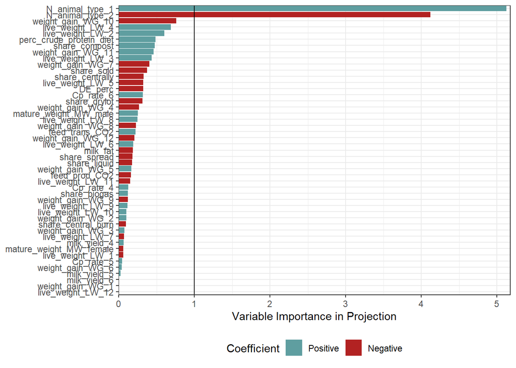

```r
input_table <- read.csv("data/livestock_ghg_input_table.csv")

plot_pls(pls_result, input_table = input_table, threshold = 0)
```

# Uncertainty

We apply a collection of functions for use in assessing uncertainty in the relationship between GHG emissions and milk yields in livestock production. We use functions from the `uncertainty` package. Install the package using `devtools::install_github("CWWhitney/uncertainty")`.

We apply the uncertainty functions on the `milk_yield` and `on_farm` variables. These come from the model results (400) of the `GHG_simulation` model results to the `in_var` (x) and an outcome variable `out_var` (y). in the model we defined `on_farm` as the sum of Carbon Dioxide Equivalent Enteric Methane Emissions from Livestock (`enteric_CH4_CO2eq`), Carbon Dioxide Equivalent Methane Emissions from Livestock Manure (`mm_CH4_CO2eq`), Carbon Dioxide Equivalent Nitrous Oxide Emissions from Livestock Manure (`mm_N2O_CO2eq`) and Carbon Dioxide Emissions from Livestock Feed Production and Transport (`feed_CO2`).

```r
in_var  <- GHG_simulation$y$milk_yield
out_var <- GHG_simulation$y$on_farm
```

## Milk_yield (x-axis) effect on on-farm GHG emissions (y-axis)

Here we use the `varscatter()` function to create a scatter plot of milk yields `in_var` (x) and GHG emissions `out_var` (y) with associated and estimated densities with loess smooth linear fits density curves. Plot made with the scatter.hist() function in the `plyr()` package (Wickham 2020) in R (R Core Team 2021). The result is a scatter plot with associated and estimated densities (using a loess smooth) given by the red dot (mean) and red ellipses (1 and 2 sigma from mean). The red line going across the plot shows the linear fit. Histograms are shown with smooth lines (loess smooth linear fits) density curves. The numeric value in the upper right gives the Spearman correlation coefficient between the influencing variable and the outcome variable.

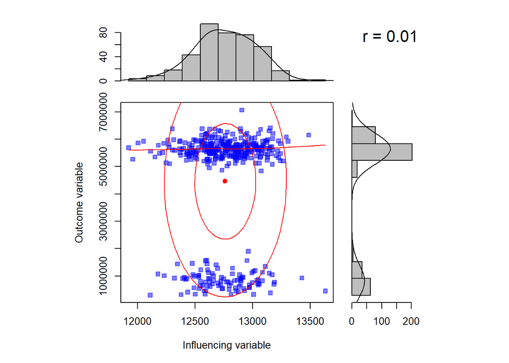

```
## [1] "Scatter plot of influencing variable (x) and outcome variable (y) with associated and estimated densities."
```

```r
uncertainty::varscatter(in_var = in_var,
                        out_var = out_var)
```

To verify the finding we use the `varkernel()` function for another type of graphical representation of the same relationship. We use the `varkernel()` function to perform a two-dimensional kernel density estimation for the expected value of GHG emissions and milk yield. The core of the process involves kernel density estimation. This is a nonparametric technique for estimating probability density functions (similar to histogram density estimation but with more dimensions). We apply this with the `kde2d()` function in the `MASS()` package (Ripley 2021). The function produces a matrix of the estimated density (z) of the expected value of the GHG emissions and milk yield. It looks slightly different than the scatter plot estimates above because the density function restricts the shape of the kernel to a normal distribution (a bivariate normal kernel).

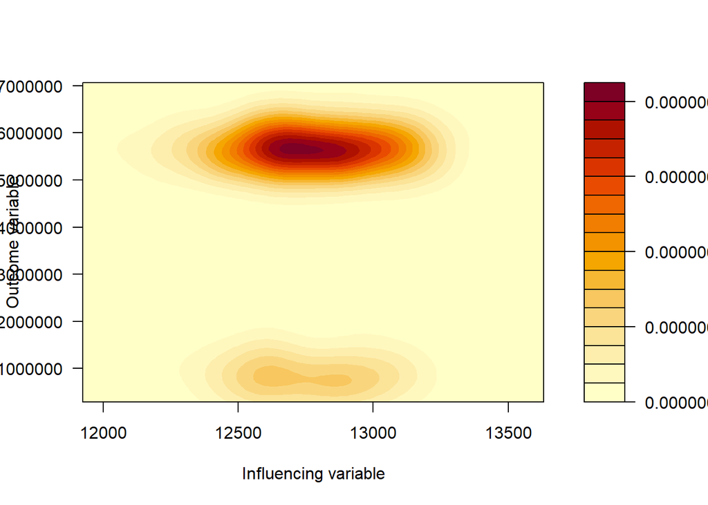

```
## [1] "Density surface plot of an expected influential variable (x) and an outcome variable of interest (y)."
```

```r
uncertainty::varkernel(in_var = in_var, out_var = out_var)
```

## Probability of GHG emissions for a given range of milk yield

We use the `varkernelslicerange()` function to show the milk yield (influencing variable `in_var` value) intervals. Here we choose a very wide distribution (the whole range of milk yields from the Monte Carlo simulation). Here we set the maximum expected value for milk yield `in_var` to 13632 and the minimum expected value to 11924.

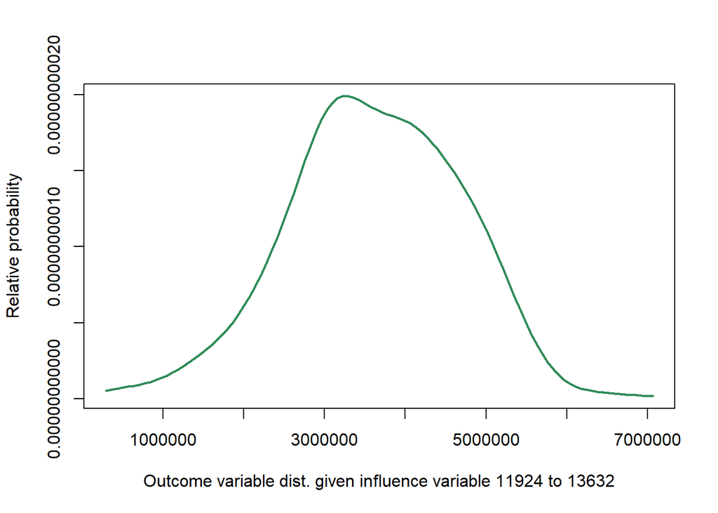

```
## [1] "Relative probability (y) of the outcome variable for the given values of the influencing variable (x)."
```

```r
uncertainty::varkernelslicerange(in_var = in_var, out_var = out_var,
                                 min_in_var = round(min(in_var)),
                                 max_in_var = round(max(in_var)))
```

`varkernelslicerange()` plots the probabilities (shown along the y-axis) for the expected value of the outcome variable `out_var` (shown along the x-axis). As with `varkernelslice()` the probability values shown are relative, not absolute measures. They are the result of cuts through the density kernel `varkernel()`, which integrates to 1.

## Influencing variable intervals

For a more specific estimate we can choose from those optimized interquartile ranges to select a range to slice from the density kernel `varkernel()`. we do that here using the `varviolin()` function to determine meaningful milk yield variable intervals and how they interact with the outcome variable GHG emissions. We do this by calculating an ‘optimal’ interval width using the interquartile range `IQR()` function in the `stats()` package.

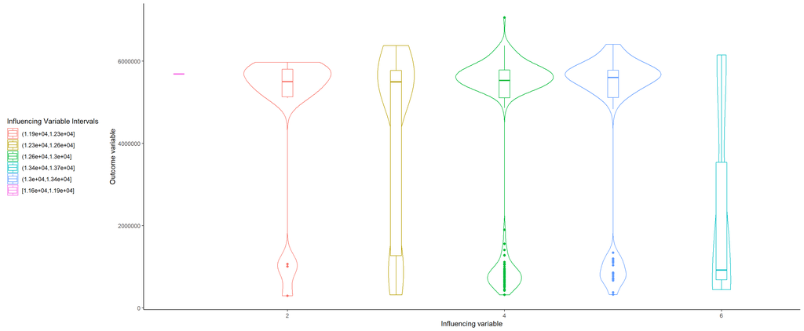

```
## [1] "Violin plots of influencing variable (x) and outcome variable (y) with IQR intervals of the influencing variable."
```

```r
uncertainty::varviolin(in_var = in_var, out_var = out_var, legend.position = "left")
```

The result of the `varviolin()` function shows violin plots of milk yield `in_var` values (x) and our outcome variable GHG emissions `out_var` (y) values. The plot was made with `ggplot2()` (Wickham et al. 2021). These offer a possible selection of milk yields and show the resulting expected GHG emissions.

This document was generated using R Markdown (Allaire et al. 2021).

# References

Allaire, JJ, Yihui Xie, Jonathan McPherson, Javier Luraschi, Kevin Ushey, Aron Atkins, Hadley Wickham, Joe Cheng, Winston Chang, and Richard Iannone. 2021. *Rmarkdown: Dynamic Documents for r*. https://CRAN.R-project.org/package=rmarkdown.

Dong, Hongmin, Joe Mangino, Tim McAllister, Jerry Hatfield, Donald Johnson, Keith Lassey, Magda Aparecida de Lima, and Anna Romanovskaya. 2006. *IPCC Guidelines for National Greenhouse Gas Inventories - Volume 4 Agriculture, Forestry and Other Land Use*. https://www.ipcc-nggip.iges.or.jp/public/2006gl/pdf/4_Volume4/V4_10_Ch10_Livestock.pdf.

IPCC. 2021. *Good Practice Guidance and Uncertainty Management in National Greenhouse Gas Inventories*. Intergovernmental Panel on Climate Change (IPCC). https://www.ipcc-nggip.iges.or.jp/public/gp/english/.

Luedeling, Eike, Lutz Goehring, Katja Schiffers, Cory Whitney, and Eduardo Fernandez. 2021. *decisionSupport: Quantitative Support of Decision Making Under Uncertainty*. http://www.worldagroforestry.org/.

R Core Team. 2021. *R: A Language and Environment for Statistical Computing*. Vienna, Austria: R Foundation for Statistical Computing. https://www.R-project.org/.

Ripley, Brian. 2021. *MASS: Support Functions and Datasets for Venables and Ripley’s MASS*. http://www.stats.ox.ac.uk/pub/MASS4/.

Wickham, Hadley. 2020. *Plyr: Tools for Splitting, Applying and Combining Data*. https://CRAN.R-project.org/package=plyr.

Wickham, Hadley, Winston Chang, Lionel Henry, Thomas Lin Pedersen, Kohske Takahashi, Claus Wilke, Kara Woo, Hiroaki Yutani, and Dewey Dunnington. 2021. *Ggplot2: Create Elegant Data Visualisations Using the Grammar of Graphics*. https://CRAN.R-project.org/package=ggplot2.

Wilkes, Andreas, Charles Odhong, Suzanne van Dijk, Simon Fraval, and Shimels Eshete Wassie. 2019. “Methods and Guidance to Support MRV of Livestock Emissions (Working Paper No. 285).” CGIAR Research Program on Climate Change, Agriculture; Food Security (CCAFS).

Wilkes, Andreas, Shimels Wassie, Charles Odhong’, Simon Fraval, and Suzanne van Dijk. 2020. “Variation in the Carbon Footprint of Milk Production on Smallholder Dairy Farms in Central Kenya.” *Journal of Cleaner Production* 265 (August): 121780. https://doi.org/10.1016/j.jclepro.2020.121780.